# Cue-selection with overt semantic primes

## Experiment

It’s exactly the same as Experiment 1 except that we provide a semantic prime for one of the target words before each critical trial (and we change the words to support this).

[Here](https://memorygame29.herokuapp.com/?skip=6) is a demonstration of the prime. It’s an overt (300ms on screen without mask) semantic prime. I selected stimuli using a free-association dataset, picking targets that were very likely to be produced for given a cue word (the cue becomes our prime). They are not subtle, e.g. “wick” primes “candle”, “teddy” primes “bear”.

Going forward, I think we should probably try to soften the prime, ideally making it subliminal. But I wanted to start by establishing the basic priming effect.

Version(s): v9.0, v9.1

## Analysis

- Dropping 7 participants with less than 50% accuracy in critical trials
- Dropping error trials
- Z-scoring fixation durations
- 52 participants and 873 trials in the analysis

Note: I’m just plotting raw means here, but the regression is still mixed effects.

# Probability of choosing the primed word

Sanity check.

| Fixed Effects | Fixed Effects Est. | Fixed Effects S.E. | Fixed Effects t val. | Fixed Effects d.f. | Fixed Effects p |
| --- | --- | --- | --- | --- | --- |
| (Intercept) | 0.487 | 0.044 | 11.033 | 51.017 | 0.000 |
| first_primed | 0.277 | 0.055 | 5.079 | 50.251 | 0.000 |

p values calculated using Satterthwaite d.f.

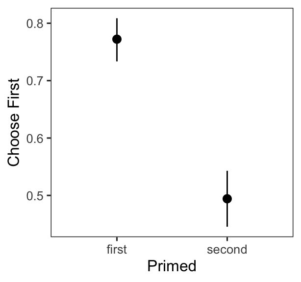

```r
prime_effect = function(data, yvar) {
    data %>%
        mutate(first_primed = int(first_primed)) %>%
        tidylmer(first_primed, {{yvar}}) %>% summ %>% smart_print
    data %>%
        ggplot(aes(primed, {{yvar}})) +
        stat_summary(fun.data=mean_cl_boot) +
        labs(x="Primed", y=pretty_name(ensym(yvar)))
}

human %>%
    filter(n_pres > 0) %>%
    mutate(choose_first = int(choose_first)) %>%
    prime_effect(choose_first)
```

# Overall fixation proportion

```r
human %>%
    filter(n_pres>1) %>%
    prime_effect(prop_first)
```

| Fixed Effects | Fixed Effects Est. | Fixed Effects S.E. | Fixed Effects t val. | Fixed Effects d.f. | Fixed Effects p |
| --- | --- | --- | --- | --- | --- |
| (Intercept) | 0.433 | 0.017 | 25.860 | 45.595 | 0.000 |
| first_primed | 0.101 | 0.025 | 4.005 | 43.850 | 0.000 |

p values calculated using Satterthwaite d.f.

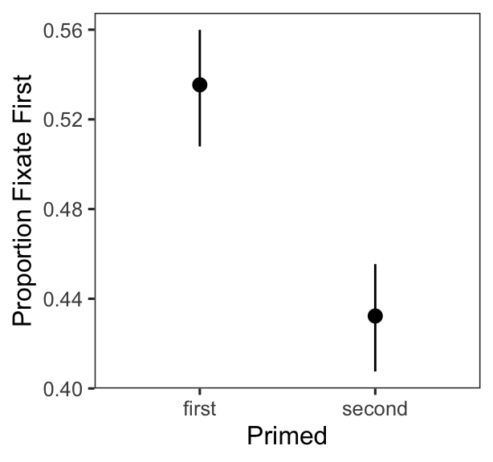

# Fixation time course

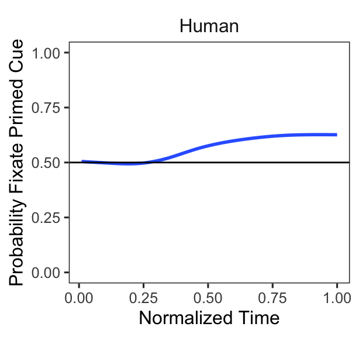

```r
normalized_timestep = function(long) {
    long %>%
        group_by(trial_id) %>%
        # this somewhat complex method ensures that all trials have exactly 100 steps
        # (this isn't true if you just round duration, as I did initially)
        mutate(percentage_complete = round(100*cumsum(duration / sum(duration)))) %>%
        mutate(n_step = diff(c(0, percentage_complete))) %>%
        uncount(n_step) %>%
        group_by(trial_id) %>%
        mutate(normalized_timestep = row_number())
}
long %>%
    filter(name == 'Human') %>%
    left_join(select(human, trial_id, first_primed, version)) %>%
    mutate(fix_primed = 1*(fix_first == first_primed)) %>%
    normalized_timestep %>%
    drop_na(strength_diff) %>%
    ggplot(aes(normalized_timestep/100, fix_primed)) +
    geom_smooth(se=F) +
    ylim(0, 1) +
    facet_grid(~name) +
    labs(x="Normalized Time", y="Probability Fixate Primed Cue") +
    geom_hline(yintercept=0.5) +
    theme(legend.position="top")
```

# Fixation durations

## First fixation

This effect is the opposite of predicted. Something weird is going on, see the interaction below.

```r
human %>%
    filter(n_pres >= 2) %>%
    prime_effect(first_pres_time)
```

| Fixed Effects | Fixed Effects Est. | Fixed Effects S.E. | Fixed Effects t val. | Fixed Effects d.f. | Fixed Effects p |
| --- | --- | --- | --- | --- | --- |
| (Intercept) | -0.113 | 0.051 | -2.195 | 36.570 | 0.035 |
| first_primed | -0.082 | 0.066 | -1.245 | 110.670 | 0.216 |

p values calculated using Satterthwaite d.f.

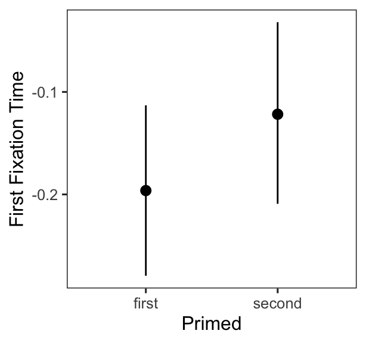

## Second fixation

In the right direction, but small and insignificant.

```r
human %>%
    filter(n_pres >= 3) %>%
    prime_effect(second_pres_time)
```

| Fixed Effects | Fixed Effects Est. | Fixed Effects S.E. | Fixed Effects t val. | Fixed Effects d.f. | Fixed Effects p |
| --- | --- | --- | --- | --- | --- |
| (Intercept) | 0.314 | 0.151 | 2.077 | 20.885 | 0.050 |
| first_primed | -0.087 | 0.175 | -0.496 | 25.144 | 0.624 |

p values calculated using Satterthwaite d.f.

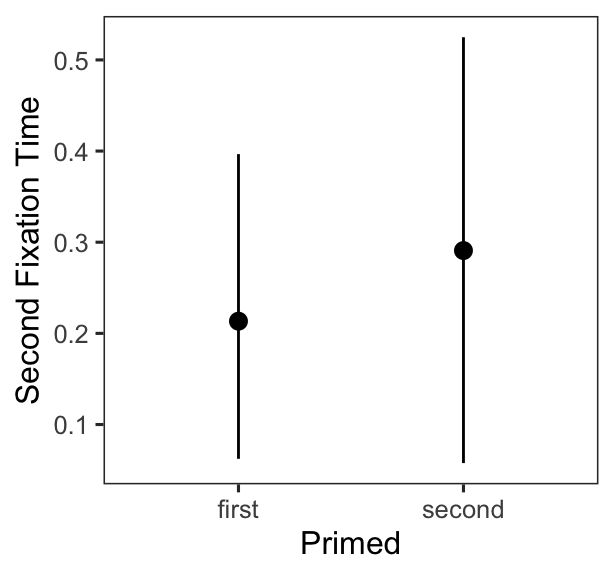

## Third fixation

Same thing.

```r
human %>%
    filter(n_pres >= 4) %>%
    prime_effect(third_pres_time)
```

| Fixed Effects | Fixed Effects Est. | Fixed Effects S.E. | Fixed Effects t val. | Fixed Effects d.f. | Fixed Effects p |
| --- | --- | --- | --- | --- | --- |
| (Intercept) | 0.074 | 0.263 | 0.282 | 12.862 | 0.782 |
| first_primed | 0.271 | 0.377 | 0.719 | 54.570 | 0.475 |

p values calculated using Satterthwaite d.f.

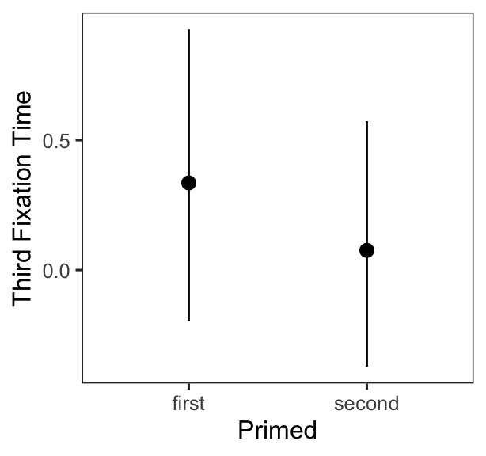

# Strength-prime interactions

For the most part, we don’t see interactions, and the main effect of the prime sticks around when accounting for strength. The interesting exception is first fixation duration.

## Choice

|  | Est. | S.E. | t val. | p |
| --- | --- | --- | --- | --- |
| (Intercept) | 0.477 | 0.021 | 22.600 | 0.000 |
| strength_first | 0.174 | 0.023 | 7.569 | 0.000 |
| first_primed | 0.300 | 0.030 | 10.118 | 0.000 |
| strength_first:first_primed | -0.036 | 0.030 | -1.207 | 0.228 |

Standard errors: OLS

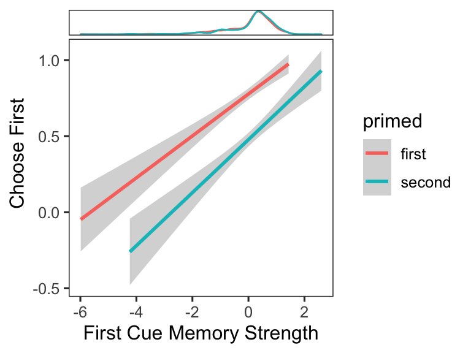

```r
prime_interaction = function(data, xvar, yvar) {
    y = ensym(yvar)
    x = ensym(xvar)
    data %>%
        mutate(first_primed = int(first_primed)) %>%
        lm(inject(!!y ~ !!x * first_primed), data=.) %>%
        summ %>% smart_print
    data %>%
        ggplot(aes({{xvar}}, {{yvar}}, color=primed)) +
        geom_smooth(method='lm') +
        labs(x=pretty_name(x), y=pretty_name(y)) +
        geom_xdensity +
        theme(legend.position="right")
}

human %>%
    filter(n_pres > 0) %>%
    mutate(choose_first = int(choose_first)) %>%
    prime_interaction(strength_first, choose_first)
```

## Overall fixation proportion

```r
human %>%
    filter(n_pres > 0) %>%
    mutate(choose_first = int(choose_first)) %>%
    prime_interaction(rel_strength, prop_first)
```

|  | Est. | S.E. | t val. | p |
| --- | --- | --- | --- | --- |
| (Intercept) | 0.590 | 0.014 | 43.001 | 0.000 |
| rel_strength | 0.065 | 0.010 | 6.677 | 0.000 |
| first_primed | 0.131 | 0.019 | 6.762 | 0.000 |
| rel_strength:first_primed | -0.008 | 0.013 | -0.582 | 0.561 |

Standard errors: OLS

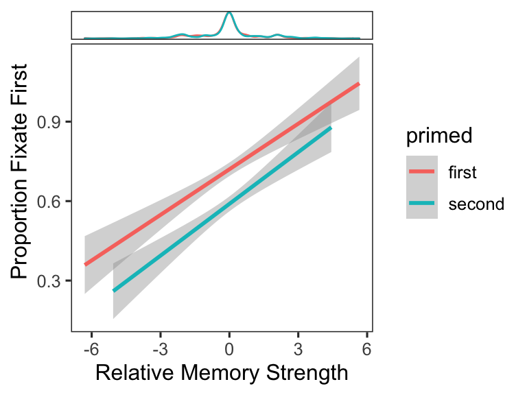

## First fixation

We have a strong negative effect of strength on first fixation duration when the first cue is primed. This is peculiar. I think it’s probably some kind of selection effect. Something like… if people have a strong memory for a primed item, the only way they could not remember it is if they mistakenly switch away quickly. Alternatively, participants could be using a strategy where they remember the first target but look at the second image to double check that the first image is actually the right cue. Note that with the explicit prime, people could know the target before even seeing a cue (this is a problem with the explicit prime).

```r
human %>%
    filter(n_pres >= 2) %>%
    prime_interaction(strength_first, first_pres_time)
```

|  | Est. | S.E. | t val. | p |
| --- | --- | --- | --- | --- |
| (Intercept) | -0.123 | 0.043 | -2.843 | 0.005 |
| strength_first | 0.028 | 0.045 | 0.624 | 0.533 |
| first_primed | -0.096 | 0.064 | -1.502 | 0.134 |
| strength_first:first_primed | -0.114 | 0.059 | -1.928 | 0.054 |

Standard errors: OLS

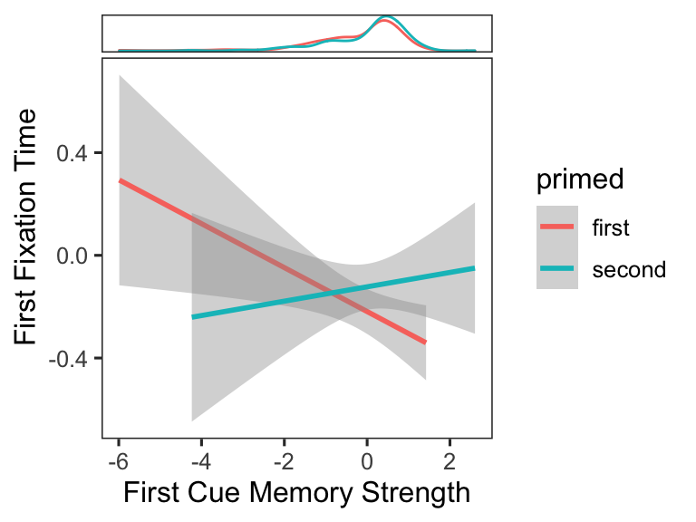

## Second fixation

```r
human %>%
    filter(n_pres >= 3) %>%
    prime_interaction(rel_strength, second_pres_time)
```

|  | Est. | S.E. | t val. | p |
| --- | --- | --- | --- | --- |
| (Intercept) | 0.314 | 0.120 | 2.616 | 0.009 |
| rel_strength | -0.038 | 0.089 | -0.433 | 0.665 |
| first_primed | -0.100 | 0.150 | -0.666 | 0.506 |
| rel_strength:first_primed | 0.010 | 0.109 | 0.095 | 0.924 |

Standard errors: OLS

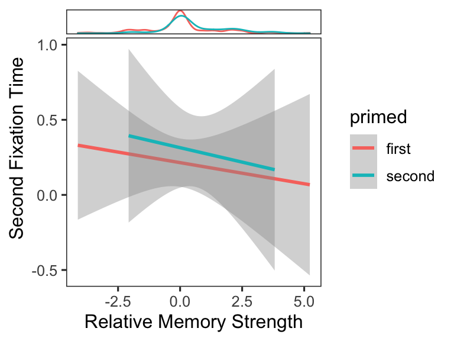

## Third fixation

```r
human %>%
    filter(n_pres >= 4) %>%
    prime_interaction(rel_strength, third_pres_time)
```

|  | Est. | S.E. | t val. | p |
| --- | --- | --- | --- | --- |
| (Intercept) | 0.054 | 0.256 | 0.213 | 0.832 |
| rel_strength | 0.165 | 0.219 | 0.754 | 0.454 |
| first_primed | 0.395 | 0.402 | 0.984 | 0.330 |
| rel_strength:first_primed | 0.041 | 0.334 | 0.122 | 0.904 |

Standard errors: OLS

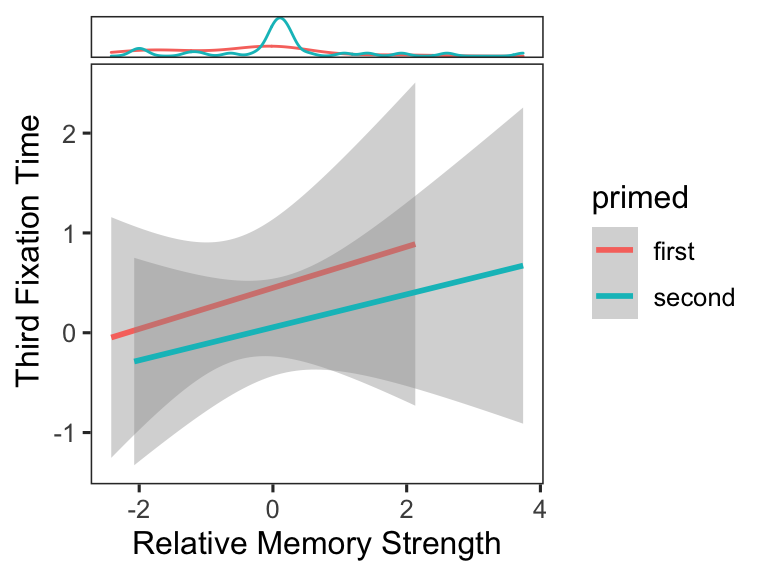

# Miscellaneous

## Awareness

We ask: “Did you notice anything about the letters that flashed in the last test round?”

```r
survey = load_data('survey')
survey %>%
    left_join(select(participants, wid, version)) %>%
    select(Q0) %>% kable
```

| Q0 |
| --- |
| The words were clues. |
| no |
| They corresponded to one of the words associated with the two pictures |
| they were related to the word attached to one of the pictures. Like “yolk” appears before the picture of a glass house that had egg attached |
| they were sceneries |
| no |
| I noticed that the words were related to the words on the pictures. |
| Yes, they associated with the answer of one of the photos |
| They were related to one of the words in the word-image pairs. |
| They weren’t words used to name things |
| nope |
| They were meant to mess with my memory. |
| Yes |
| They were words that had the same meaning as the word in the picture. |
| NA |
| related with the word |
| Some of the words were related to an image. Perhaps all of them, but I often did not check both. |
| They were related to one of the images |
| none |
| they were hints for one of the pictures |
| They were often synonyms to the words in one of the pictures. |
| No i was too focused on remembering the words with the pictures |
| no |
| there were all related to the ones in the study |
| yes |
| not really |
| they were related to one of the words on the images |
| The words always related to one of the images, I.E. mower and one of the images’ words was lawn |
| yes, the words that flashed related to the words associated with one of the images. |
| no |
| Yes, I noticed them but was concentrating too hard on the buttons to push for the current round. |
| they were related to one of the target words |
| I was honestly too focused on what the next images were coming up. So I did not realize the words and make a connection to them |
| No |
| some of them helped me remember one of the images word pairs. Some of them didnt help me but i knew the other image’s word. |
| They associated with one of the words that matched with the images |
| The flashes of words were related to the word attached to one of the pictures |
| They were none of the words related to the picture. |
| The letters spelled words that were related to words of one of the two pictures. |
| they were hints to the answers. |
| No |
| They were all related to at least one of the pictures |
| no |
| I didn’t notice |
| Yes - the words that flashed on the screen were a hint to one of the answers. |
| They were clues to one of the picture’s word |
| They related to at least one of the images |
| some seem to be hints to the answers. I’m guessing the ones that were not were a hint to the other photo. I only looked at the second photo once |
| they were somewhat related to one of the words on the image. |
| seemed to be relevant to one of the matching words |
| yes they were clues! I didn’t pay attention to them until halfway through the round though. |
| yes was a hint |
| yes |
| Yes |
| it wasn’t something special |
| No |
| They were references to the correct word for one of the images |
| They related to one of the images. |
| yes |
| They gave hints to the pictures |

## Response types

We see a similar accuracy rate to Experiment 1.

```r
raw_df %>%
    with((proportions(table(name, response_type), margin=1))) %>%
    kable(digits=2)
```

|  | correct | intrusion | other | timeout | empty |
| --- | --- | --- | --- | --- | --- |
| Optimal | 0.96 | 0.00 | 0.00 | 0.04 | 0 |
| Human | 0.88 | 0.06 | 0.02 | 0.03 | 0 |
| Random | 0.97 | 0.00 | 0.00 | 0.03 | 0 |

## Reaction time

Similar as well.

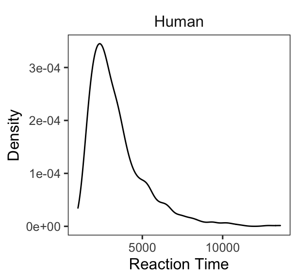

```r
human %>%
    ggplot(aes(rt)) +
    geom_density() +
    facet_grid(~name) +
    labs(x="Reaction Time", y="Density")
```

## Number of fixations

Similar.

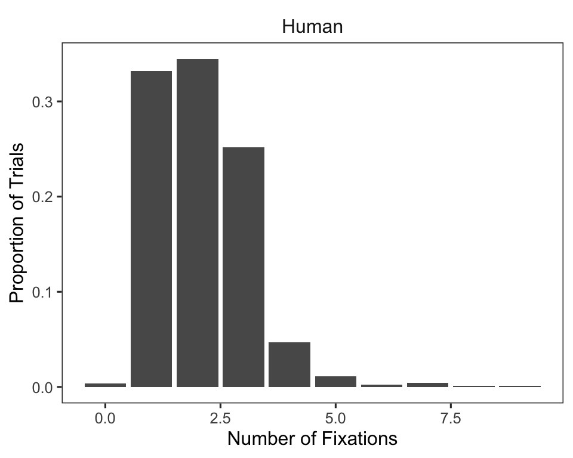

```r
human %>%
    filter(n_pres < 10) %>%
    ggplot(aes(n_pres, ..prop..)) +
    geom_bar() +
    facet_grid(~name) +
    labs(x="Number of Fixations", y="Proportion of Trials")
```